# Estudo do Estilo Arquitetural Cliente-Servidor

LP4A/PUCSP, ItaloSV, 2018

# 1 Camadas de uma Rede de Comunicação

- ISO - International Organization for Standardization
- OSI - Open Systems Interconnection

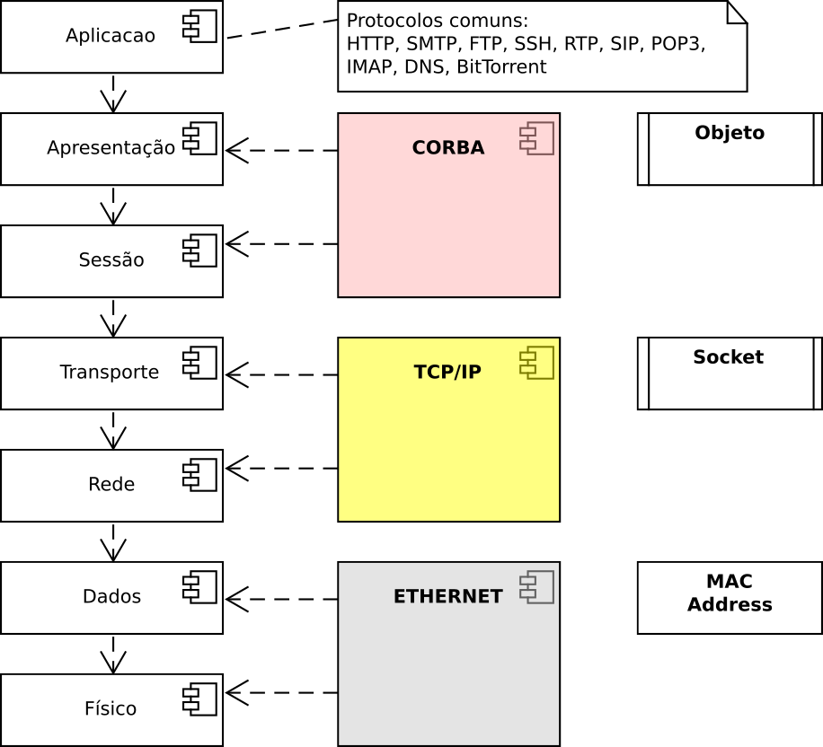

Figura 1: Camadas ISO/OSI

**Cliente-servidor, TCP/IP e *socket*** Uma arquitetura no estilo cliente-servidor com *sockets* TCP/IP contém os elementos destacados no diagrama de componentes (DCP) fig. 2.

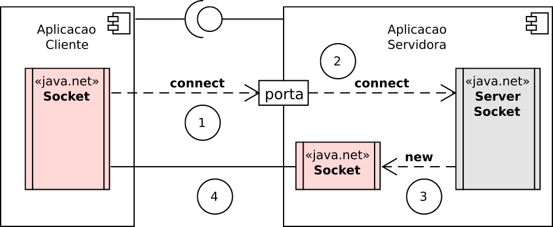

Figura 2: Arquiteturas Cliente-Servidor

A ideia de *socket* foi proposta em Berkeley, 1981. Ela abstrai a comunicação entre processos de uma rede no nível TCP/IP. Segue a conhecida filosofia “transmita sem ‘rezar’”—existe garantia de entrega dos pacotes transmitidos pela rede.

**Fluxos de dados de um *socket*** Um detalhe da comunicação por *sockets* na tecnologia Java é mostrado no diagrama da fig. 3.

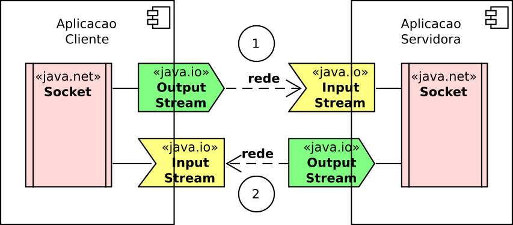

Figura 3: Comunicação por Sockets

Neste diagrama, observamos que objetos da classe `Socket` encontram-se associados a um fluxo de dados de entrada (`InputStream`) e a outro de saída (`OutputStream`). É por meio destes objetos que a comunicação entre dois *sockets* efetivamente acontece.

# 2 Experimento Cliente-Servidor (Sequencial)

Vamos projetar uma aplicação cliente-servidor capaz de informar a média em LP4 dos alunos, trabalhando em modo sequencial. A aplicação será constituída por dois componentes-aplicação.

## 2.1 Aplicação-Servidor

Nesta seção, implementaremos o componente-servidor.

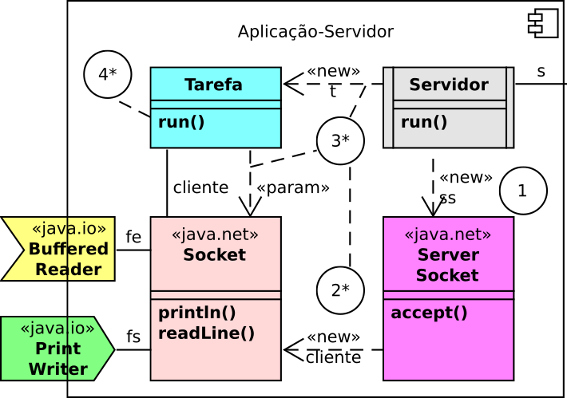

Experimento: Arquitetura do Servidor

### 2.1.1 Classe `AplServidor`

A lógica principal da aplicação-servidor apenas instancia um objeto `Servidor` e comanda a sua execução (lst. 1).

Listagem 1: Componente Servidor

```java
// cs1::mf::AplServidor::
import java.io.IOException;

public class AplServidor {

    public static void main(String[] args) throws IOException {
        Servidor apl = new Servidor();
        apl.run();
    }
}
```

### 2.1.2 Classe `Servidor`

Listagem 2: Classe servidor de médias LP4

```java
// cs1::mf::Servidor::
import java.io.IOException;
import java.net.ServerSocket;
import java.net.Socket;

public class Servidor {

    public void run() throws IOException {
        ServerSocket ss = new ServerSocket(9001);
        int n = 0;
        while (true) {
            String nomeFluxo = Thread.currentThread().getName();
            String s = String.format("Aguardando conexões (%s)...", nomeFluxo);
            System.out.println(s);
            Socket cliente = ss.accept(); // <--(1) WAIT
            System.out.println("Atendendo cliente " + ++n); // <--(2)
            TarefaServidor t = new TarefaServidor(cliente);
            t.run();
        }
    }
}
```

### 2.1.3 Classe `TarefaServidor`

O atendimento é feito quando se executam as instruções desta classe, que possui a interface exigida mostrada na lst. 3.

Listagem 3: Interface exigida

```java
// cs1::mf::TarefaServidor::
import java.io.BufferedOutputStream;
import java.io.BufferedReader;
import java.io.IOException;
import java.io.InputStream;
import java.io.InputStreamReader;
import java.io.OutputStream;
import java.io.PrintWriter;
import java.net.Socket;
// class TarefaServidor {
```

**Definição dos fluxos de dados do cliente** Na construção da tarefa, associamos os dois fluxos de dados (de entrada e de saída) do *socket* de atendimento ao cliente. É por meio destes fluxos que ocorrerá a comunicação (lst. 4, lst. 5 e lst. 6).

Listagem 4: Associação com os fluxos de dados

```java
    // cs1::mf::TarefaServidor::
    TarefaServidor(Socket c) throws IOException {
        fluxoEntrada = definirFluxoEntrada(c);
        fluxoSaida = definirFluxoSaida(c);
    }
    BufferedReader fluxoEntrada;
    PrintWriter fluxoSaida;
```

Listagem 5: Definição do fluxo de entrada

```java
    // cs1::mf::TarefaServidor::
    BufferedReader definirFluxoEntrada(Socket cliente) throws IOException {
        InputStream is = cliente.getInputStream();
        InputStreamReader istream = new InputStreamReader(is);
        return new BufferedReader(istream);
    }
```

Listagem 6: Definição do fluxo de saída

```java
    // cs1::mf::TarefaServidor::
    PrintWriter definirFluxoSaida(Socket cliente) throws IOException {
        OutputStream os = cliente.getOutputStream();
        BufferedOutputStream ostream = new BufferedOutputStream(os);
        // flush por write
        return new PrintWriter(os, true);
    }
```

**Interpretador de comandos** No método `run()` implementamos um interpretador de comandos enviados pelo cliente. No presente ensaio, apenas um comando será reconhecido: **mf**, interpretado como um pedido de acesso à media de LP4 (lst. 7).

Listagem 7: Lógica do intepretador de comandos do servidor

```java
    // cs1::mf::TarefaServidor::
    public void run() throws IOException {
        String cmd = fluxoEntrada.readLine();
        if (cmd != null) {
            System.out.println(cmd);
            switch (cmd) {
                case "mf":
                    double mf = Math.random() * 10.0;
                    String resultado = String.format("%.1f", mf);
                    fluxoSaida.println(resultado);
                    break;
                default:
                    fluxoSaida.println("Não sei....");
            }
        }
    }
```

## 2.2 Aplicação-Cliente

Nesta seção, implementaremos o componente-cliente.

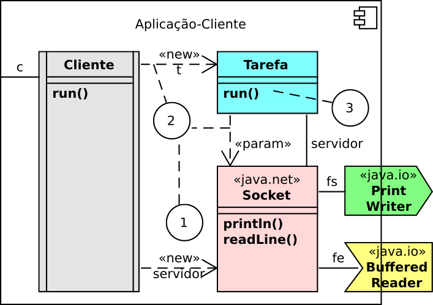

Experimento: Arquitetura do Cliente

### 2.2.1 Classe `AplCliente`

Listagem 8: Componente Cliente

```java
// cs1::mf::AplCliente::
import java.io.IOException;

public class AplCliente {

    public static void main(String[] args) throws IOException {
        Cliente c = new Cliente();
        c.run();
    }
}
```

### 2.2.2 Classe `Cliente`

A lógica efetiva de solicitação de médias de LP4 encontra-se codificada nas classes `Cliente` e `TarefaCliente`. A primeira abre uma conexão contra o servidor e instancia um objeto que conhece a lógica de solicitação lst. 9.

Listagem 9: Classe cliente para solicitação de médias LP4

```java
// cs1::mf::Cliente::
import java.io.IOException;
import java.net.Socket;

class Cliente {

    public void run() throws IOException {
        System.out.println("Conectando com o servidor de notas LP4...");
        try (Socket servidor = new Socket("localhost", 9001)) {
            TarefaCliente t = new TarefaCliente(servidor);
            t.run();
        } // servidor.close()
    }
}
```

Alguns dos detalhes da instanciação do *socket* do servidor e da tarefa a ser realizada são ilustrados no diagrama mostrado na fig. 4.

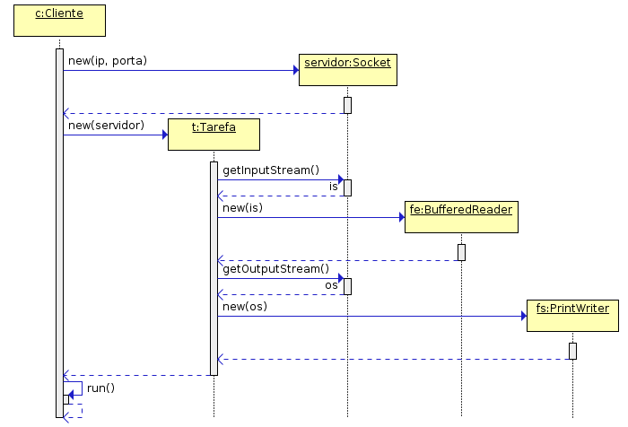

Figura 4: Configuração da aplicação-cliente

### 2.2.3 Classe `TarefaCliente`

A solicitação de médias é feita quando se executam as instruções desta classe, que possui a interface exigida mostrada na lst. 10.

Listagem 10: Interface exigida

```java
// cs1::mf::TarefaCliente::
import java.io.BufferedOutputStream;
import java.io.BufferedReader;
import java.io.IOException;
import java.io.InputStream;
import java.io.InputStreamReader;
import java.io.OutputStream;
import java.io.PrintWriter;
import java.net.Socket;
// class TarefaCliente {
```

**Definição dos fluxos de dados do servidor** Na construção da tarefa, associamos os dois fluxos de dados (de entrada e de saída) do *socket* de atendimento do servidor. É por meio destes fluxos que ocorrerá a comunicação (lst. 11, lst. 12 e lst. 13).

Listagem 11: Associação com os fluxos de dados

```java
    // cs1::mf::TarefaCliente::
    TarefaCliente(Socket servidor) throws IOException {
        fluxoEntrada = definirFluxoEntrada(servidor);
        fluxoSaida = definirFluxoSaida(servidor);
    }
    BufferedReader fluxoEntrada;
    PrintWriter fluxoSaida;
```

Listagem 12: Definição do fluxo de entrada

```java
    // cs1::mf::TarefaCliente
    public BufferedReader definirFluxoEntrada(Socket socket) throws IOException {
        InputStream is = socket.getInputStream();
        InputStreamReader istream = new InputStreamReader(is);
        return new BufferedReader(istream);
    }
```

Listagem 13: Definição do fluxo de saída

```java
    // cs1::mf::TarefaCliente
    public PrintWriter definirFluxoSaida(Socket socket) throws IOException {
        OutputStream os = socket.getOutputStream();
        BufferedOutputStream ostream = new BufferedOutputStream(os);
        // flush por write
        return new PrintWriter(ostream, true);
    }
```

**Comando de solicitação de média** No método `run()` implementamos o comando a ser enviado para o servidor, solicitando a média de LP4. No presente ensaio, apenas um comando será enviado: **mf**, interpretado como um pedido de acesso à media de LP4 (lst. 14).

Listagem 14: Lógica do comando de solicitação de médias LP4

```java
    // cs1::mf::TarefaCliente::
    public void run() throws IOException {
        String comando = "mf";
        fluxoSaida.println(comando);
        //long x = System.currentTimeMillis();
        String mf = fluxoEntrada.readLine();
        //long y = System.currentTimeMillis();
        //System.out.println("Ping médio= " + (y - x) / 10 + "ms");
        System.out.println("Média final (LP4)= " + mf);
    }
```

## 2.3 Considerações

1. Execute a aplicação-servidor e, em seguida, a aplicação-cliente. Qual a sua “média” em LP4?
2. Altere a aplicação-cliente, acrescentando um elemento JavaFX que solicite o IP da aplicação-servidor.
3. Acrescente, também, um elemento visual para mostrar a média recebida do servidor.